# Creation and exploration of the quant file

Charlotte S.

7 février 2018

### **To Read BeforHand

**Aim of this document:** This sheet has been created to generate automatically the “Quant” file based on the TCD data. Moreover some exploarion of the data are provided at the end of this document  
**WARNING:** Before uploading the file in this calculation sheet (put the name of the function), please check with the TCD_cleanR that the TCD.csv does **NOT** contain any error in all the **CONCLUSIONS** (this task may require several run of utilisation of the function TCD_cleanR).

### **Preparation of the data**

#### 1. Open and set the TCD file

**WARNING:** Before uploading the TCD file, please check with the TCD_cleanR that the TCD.csv does **NOT** contain any error in all the **CONCLUSIONS** (this task may require several run of utilisation of the function TCD_cleanR).

```r
# tkmessageBox(message = "Choose a quant file", type = "ok")
# TCDpath <- tclvalue(tkgetOpenFile())
# if (!nchar(TCDpath)) {
#  tkmessageBox(message = "No file was selected!")
# } else {
#  tkmessageBox(message = paste("The file selected was", TCDpath))
# }
TCDpath <- "/home/cha/Dropbox/Post-doc_Danemark/Results/Script/TCD.csv"
TCD <- read.csv(file = TCDpath, h = T, dec = ".", sep = ",")
Identifier.1 <- colnames(TCD)[3] # first identifer name (e.g. box name or standard used)
Identifier.2 <- colnames(TCD)[4] # Second identifer name (i.e. place of the sample in the box)
```

The TCD file chosen is /home/cha/Dropbox/Post-doc_Danemark/Results/Script/TCD.csv

#### 2. Open and set the quantitative file

**WARNING:** Before uploading the weight file, please check that the order in TCD file and weight files are the same (checked in the next calculation but the calculations will be stop if this condition is not respected).

```r
# tkmessageBox(message = "Choose the file containing the weight of your sample", type = "ok")
# weightPath <- tclvalue(tkgetOpenFile())
# if (!nchar(weightPath)) {
#  tkmessageBox(message = "No file was selected!")
# } else {
#  tkmessageBox(message = paste("The file selected was", weightPath))
# }
weightPath <- "/home/cha/Dropbox/Post-doc_Danemark/Results/Script/weight.csv"
weightData <- read.csv(weightPath, h = T, dec = ".", sep = ",")
nRow.weightData <- nrow(weightData)
```

The TCD file chosen is /home/cha/Dropbox/Post-doc_Danemark/Results/Script/weight.csv

#### 3. Create the sample table

This table will finally give access to the “Quant results”, mg N/kg of dry sample and mg C/kg of dry sample, and C/N

```r
identifier.2.NonVide <- which(!is.null(TCD[,Identifier.2]) & TCD[,Identifier.2] != "")

TCD_dataSample <- data.frame(TCD[identifier.2.NonVide,])

nbRow.TCD_dataSample <- nrow(TCD_dataSample)

id.previous.1 <- "NA"
id.previous.2 <- "NA"

temporary.TCDtable <- data.frame(matrix(NA, ncol = 4))

 k <- 1

for(x in 1:nbRow.TCD_dataSample) {

  id.1 <- as.character(TCD_dataSample[x,]$Identifier.1)
  id.2 <- as.character(TCD_dataSample[x,]$Identifier.2)

  if(!strcmp(id.1,id.previous.1) | !strcmp(id.2, id.previous.2)){

    toAdd <- c(id.1, id.2, TCD_dataSample[x,]$rArea.Flash.TCD, TCD_dataSample[x+1,]$rArea.Flash.TCD)

    temporary.TCDtable[k,] <- toAdd

    k <- k + 1
  }

  id.previous.1 <- id.1
  id.previous.2 <- id.2

}

 nRow.temporary.TCDtable <- nrow(temporary.TCDtable)

 temporary.TCDtable <- cbind(seq(1:nRow.temporary.TCDtable), temporary.TCDtable)

 colnames(temporary.TCDtable) <- c("Analysis.Rank", colnames(TCD)[3:4], "Area.Flash.TCD.N", "Area.Flash.TCD.C")

 temporary.TCDtable$Area.Flash.TCD.N <- as.numeric(as.character(temporary.TCDtable$Area.Flash.TCD.N))
 temporary.TCDtable$Area.Flash.TCD.C <- as.numeric(as.character(temporary.TCDtable$Area.Flash.TCD.C))
 datatable(temporary.TCDtable, options = list(pageLength = 5))
```

|  | Analysis.Rank | Identifier.1 | Identifier.2 | Area.Flash.TCD.N | Area.Flash.TCD.C |
| --- | --- | --- | --- | --- | --- |
| 1 | 1 | Sirot_Box 1 | A1 | 68861 | 540027 |
| 2 | 2 | Sirot_Box 1 | A2 | 143291 | 1107008 |
| 3 | 3 | Sirot_Box 1 | A3 |  |  |
| 4 | 4 | Sirot_Box 1 | A4 | 94151 | 874736 |
| 5 | 5 | Sirot_Box 1 | A5 | 17480 | 245684 |
| 6 | 6 | Sirot_Box 1 | A6 | 26231 | 355703 |
| 7 | 7 | Sirot_Box 1 | A7 | 24535 | 332567 |
| 8 | 8 | Sirot_Box 1 | A8 | 22077 | 307710 |
| 9 | 9 | Sirot_Box 1 | A9 | 27015 | 375740 |
| 10 | 10 | Sirot_Box 1 | A10 | 24170 | 319901 |

[output cut: 58 more lines]

#### 4. check the outliers

Here check graphically that there is no outlier

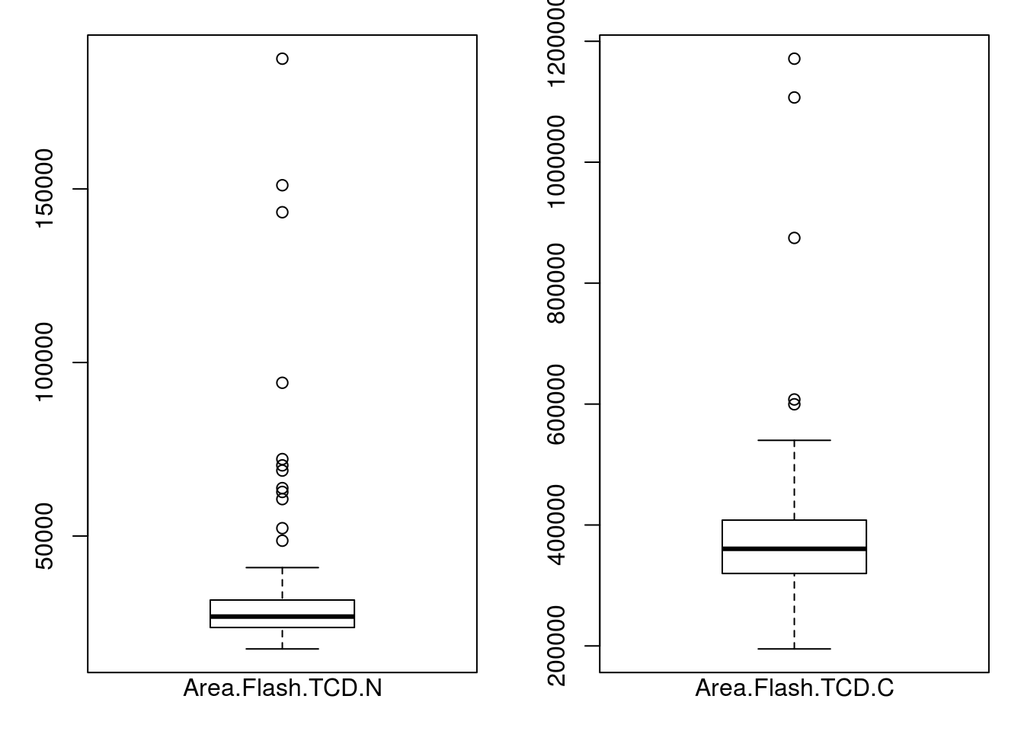

```r
par(mfrow = c(1,2), mar = c(2,3,1.2,1.2))
boxplot(temporary.TCDtable$Area.Flash.TCD.N)
mtext("Area.Flash.TCD.N", side = 1)
boxplot(temporary.TCDtable$Area.Flash.TCD.C, xlab="Area.Flash.TCD.C")
mtext("Area.Flash.TCD.C", side = 1)
```

#### 5. Copy paste the column in temporary.TCDtable and check the validity

```r
error <- 0 # flag for error
if(nRow.temporary.TCDtable != nRow.weightData) {
  error <- 1
} else {
  for(i in 1:nRow.temporary.TCDtable){
    if(!strcmp(temporary.TCDtable[i,]$Identifier.2,as.character(weightData[i,]$Box.pos))){
      error <- 1
    }
  }
  temporary.TCDtable <- cbind(temporary.TCDtable, weightData$Name, weightData$Measured.Weigth..mg.)

  colnames(temporary.TCDtable)[6:7] <- c("sampleName", "SampleWeight")
}
```

So here is there a problem ?

```
## [1] "The two files matches. It seems that there is no error."
```

#### 5. Import the value of the background

```r
backgroundValues <- inputs("background values", "N background", "C background")
# backgroundValues <- c(0, 1167)
```

Your background value for N is 0  
Your background value for C is 1600

#### 6. Correction of the values Area.Flash.TCD.C & Area.Flash.TCD.N with the background

```r
corrected.N <- temporary.TCDtable$Area.Flash.TCD.N - backgroundValues[1]

corrected.C <- temporary.TCDtable$Area.Flash.TCD.C - backgroundValues[2]

temporary.TCDtable <- cbind(temporary.TCDtable, corrected.N, corrected.C)

colnames(temporary.TCDtable)[8:9] <- c("Corrected.Area.N", "Corrected.Area.C")
```

#### 7. Creation of the GelA table (for a linear regression)

```r
content.GelA <- inputs("N and C content in GelA", "N value", "C value")
# content.GelA <- c(0.16, 0.42)
```

Your content.GelA value for N is 0.16  
Your content.GelA value for C is 0.42

```r
GelA.table <- data.frame()

for(i in 1:nRow.temporary.TCDtable) {
  if(temporary.TCDtable[i,]$sampleName == "GEL A") {
    GelA.table <- rbind(GelA.table, temporary.TCDtable[i,])
  } else {}
}

colnames(GelA.table) <- colnames(temporary.TCDtable)

toPaste <- c(0,0, 0, backgroundValues, NA, 0, backgroundValues)

GelA.table <- rbind(toPaste, GelA.table)

GelA.table[1, 2:3] <- c("Blank", "Blank")

mg.N.perCup <- GelA.table$SampleWeight * content.GelA[1] * 1000
mg.C.perCup <- GelA.table$SampleWeight * content.GelA[2] * 1000

GelA.table <- cbind(GelA.table, mg.N.perCup, mg.C.perCup)
write.csv(GelA.table, file = "GelA.table.csv")
datatable(GelA.table, options = list(pageLength = 5))
```

|  | Analysis.Rank | Identifier.1 | Identifier.2 | Area.Flash.TCD.N | Area.Flash.TCD.C | sampleName | SampleWeight | Corrected.Area.N | Corrected.Area.C | mg.N.perCup | mg.C.perCup |
| --- | --- | --- | --- | --- | --- | --- | --- | --- | --- | --- | --- |
| 1 | 0 | Blank | Blank | 0 | 1600 |  | 0 | 0 | 1600 | 0 | 0 |
| 11 | 1 | Sirot_Box 1 | A1 | 68861 | 540027 | GEL A | 0.332 | 68861 | 538427 | 53.12 | 139.44 |
| 2 | 2 | Sirot_Box 1 | A2 | 143291 | 1107008 | GEL A | 0.712 | 143291 | 1105408 | 113.92 | 299.04 |
| 3 | 3 | Sirot_Box 1 | A3 |  |  | GEL A | 0.307 |  |  | 49.12 | 128.94 |
| 13 | 13 | Sirot_Box 1 | B1 | 60638 | 506453 | GEL A | 0.291 | 60638 | 504853 | 46.56 | 122.22 |
| 14 | 14 | Sirot_Box 1 | B2 | 24224 | 228073 | GEL A | 0.124 | 24224 | 226473 | 19.84 | 52.08 |
| 25 | 25 | Sirot_Box 1 | C1 | 52257 | 430368 | GEL A | 0.304 | 52257 | 428768 | 48.64 | 127.68 |
| 26 | 26 | Sirot_Box 1 | C2 | 72170 | 599616 | GEL A | 0.511 | 72170 | 598016 | 81.76 | 214.62 |
| 27 | 27 | Sirot_Box 1 | C3 | 70362 | 607580 | GEL A | 0.362 | 70362 | 605980 | 57.92 | 152.04 |
| 37 | 37 | Sirot_Box 1 | D1 | 48653 | 407815 | GEL A | 0.331 | 48653 | 406215 | 52.96 | 139.02 |

[output cut: 6 more lines]

#### 8. Linear regression for N

```r
model.N <- lm(GelA.table$Area.Flash.TCD.N ~ GelA.table$mg.N.perCup)
summary(model.N)
```

```
##
## Call:
## lm(formula = GelA.table$Area.Flash.TCD.N ~ GelA.table$mg.N.perCup)
##
## Residuals:
##    Min     1Q Median     3Q    Max
## -32853 -13772  -7632   -121 112795
##
## Coefficients:
##                        Estimate Std. Error t value Pr(>|t|)
## (Intercept)             12327.7    18475.6   0.667  0.51629
## GelA.table$mg.N.perCup   1133.7      302.5   3.748  0.00243 **
## ---
## Signif. codes:  0 '***' 0.001 '**' 0.01 '*' 0.05 '.' 0.1 ' ' 1
##
## Residual standard error: 36430 on 13 degrees of freedom
##   (1 observation deleted due to missingness)
## Multiple R-squared:  0.5194, Adjusted R-squared:  0.4825
## F-statistic: 14.05 on 1 and 13 DF,  p-value: 0.002435
```

```r
Intercept.N <- summary(model.N)$coefficients[1]
Slope.N <- summary(model.N)$coefficients[2]
```

The parameter of the model: **Intercept = 1.232774210^{4}**, **slope = 1133.7452635**

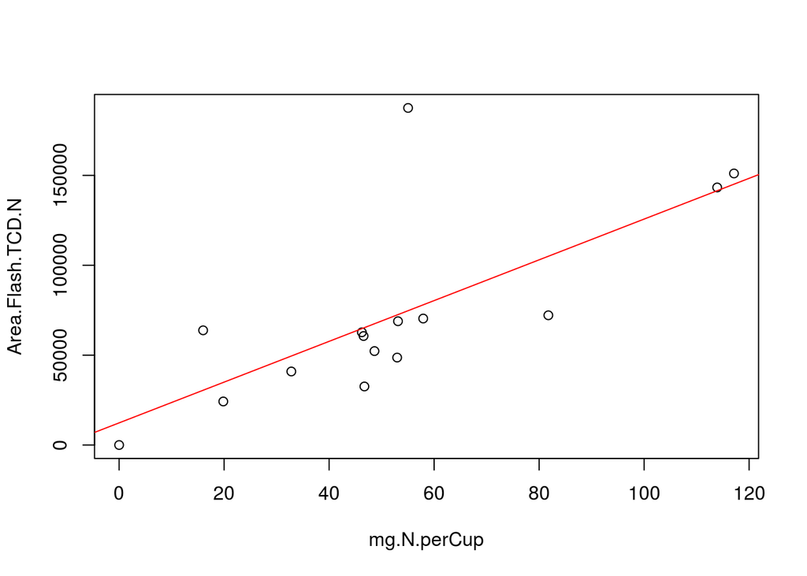

#### 9. Linear regression for C

```r
model.C <- lm(GelA.table$Area.Flash.TCD.C ~ GelA.table$mg.C.perCup)
summary(model.C)
```

```
##
## Call:
## lm(formula = GelA.table$Area.Flash.TCD.C ~ GelA.table$mg.C.perCup)
##
## Residuals:
##     Min      1Q  Median      3Q     Max
## -190937  -64277    3630   44038  302831
##
## Coefficients:
##                        Estimate Std. Error t value Pr(>|t|)
## (Intercept)             69392.9    65498.2   1.059     0.31
## GelA.table$mg.C.perCup   3248.0      405.8   8.005 3.74e-06 ***
## ---
## Signif. codes:  0 '***' 0.001 '**' 0.01 '*' 0.05 '.' 0.1 ' ' 1
##
## Residual standard error: 128300 on 12 degrees of freedom
##   (2 observations deleted due to missingness)
## Multiple R-squared:  0.8423, Adjusted R-squared:  0.8291
## F-statistic: 64.08 on 1 and 12 DF,  p-value: 3.737e-06
```

```r
Intercept.C <- summary(model.C)$coefficients[1]
Slope.C <- summary(model.C)$coefficients[2]
```

The parameter of the model: **Intercept = 6.939289810^{4}**, **slope = 3247.9905665**

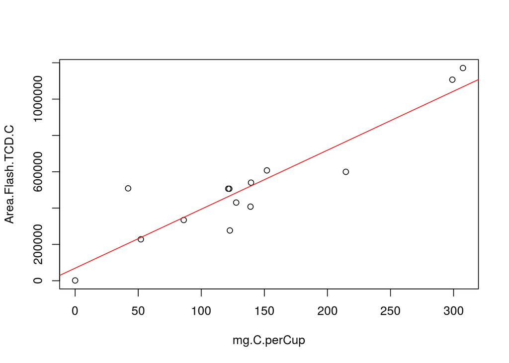

#### 10. calculation of µg N/Cup, µg C/Cup and C/N

```r
Weight.N.perCup <- temporary.TCDtable$Corrected.Area.N/Slope.N
Weight.C.perCup <- temporary.TCDtable$Corrected.Area.C/Slope.C

Weight.N.kg <- Weight.N.perCup/temporary.TCDtable$SampleWeight*1000
Weight.C.kg <- Weight.C.perCup/temporary.TCDtable$SampleWeight*1000

C.N.Ratio <- Weight.C.kg/Weight.N.kg

temporary.TCDtable <- cbind(temporary.TCDtable,Weight.N.perCup, Weight.C.perCup, Weight.N.kg, Weight.C.kg, C.N.Ratio)

write.csv(temporary.TCDtable, file = "temporary.TCDtable.csv")
datatable(temporary.TCDtable, options = list(pageLength = 5))
```

|  | Analysis.Rank | Identifier.1 | Identifier.2 | Area.Flash.TCD.N | Area.Flash.TCD.C | sampleName | SampleWeight | Corrected.Area.N | Corrected.Area.C | Weight.N.perCup | Weight.C.perCup | Weight.N.kg | Weight.C.kg | C.N.Ratio |
| --- | --- | --- | --- | --- | --- | --- | --- | --- | --- | --- | --- | --- | --- | --- |
| 1 | 1 | Sirot_Box 1 | A1 | 68861 | 540027 | GEL A | 0.332 | 68861 | 538427 | 60.7376297080687 | 165.772341073416 | 182944.667795388 | 499314.280341615 | 2.72931857680634 |
| 2 | 2 | Sirot_Box 1 | A2 | 143291 | 1107008 | GEL A | 0.712 | 143291 | 1105408 | 126.387297577713 | 340.335963837777 | 177510.2494069 | 477999.949210361 | 2.69280196950578 |
| 3 | 3 | Sirot_Box 1 | A3 |  |  | GEL A | 0.307 |  |  |  |  |  |  |  |
| 4 | 4 | Sirot_Box 1 | A4 | 94151 | 874736 | H_1998_1 | 0.538 | 94151 | 873136 | 83.0442278596648 | 268.823440866595 | 154357.300854395 | 499671.82317211 | 3.23711169090375 |
| 5 | 5 | Sirot_Box 1 | A5 | 17480 | 245684 | H_1998_3 | 0.555 | 17480 | 244084 | 15.4179254918901 | 75.1492330409948 | 27780.0459313334 | 135404.023497288 | 4.87414685461568 |
| 6 | 6 | Sirot_Box 1 | A6 | 26231 | 355703 | H_1998_5 | 0.63 | 26231 | 354103 | 23.1365905936938 | 109.022176248814 | 36724.7469741172 | 173051.073410815 | 4.71211070651563 |
| 7 | 7 | Sirot_Box 1 | A7 | 24535 | 332567 | H_1998_8 | 0.685 | 24535 | 330967 | 21.6406637267461 | 101.899002850981 | 31592.2098200673 | 148757.668395593 | 4.70868195807887 |
| 8 | 8 | Sirot_Box 1 | A8 | 22077 | 307710 | H_1998_10 | 0.639 | 22077 | 306110 | 19.4726282084929 | 94.2459633821919 | 30473.5965704115 | 147489.770551161 | 4.83992003406539 |
| 9 | 9 | Sirot_Box 1 | A9 | 27015 | 375740 | H_2001_29 | 0.896 | 27015 | 374140 | 23.8281039567168 | 115.191221259721 | 26593.8660231214 | 128561.630870225 | 4.83425880082458 |
| 10 | 10 | Sirot_Box 1 | A10 | 24170 | 319901 | H_2001_30 | 0.629 | 24170 | 318301 | 21.3187219187061 | 97.9993609830292 | 33893.0396163849 | 155801.845759983 | 4.59686848755411 |

[output cut: 58 more lines]

### **Exploration of the data**

Split the temporary.TCDtable in samples and GelA for only keeping the samples:

```r
TCDtable <- temporary.TCDtable[which(temporary.TCDtable$sampleName != "GEL A"),]
```

#### 1. Corrected.Area.N ~ SampleWeight

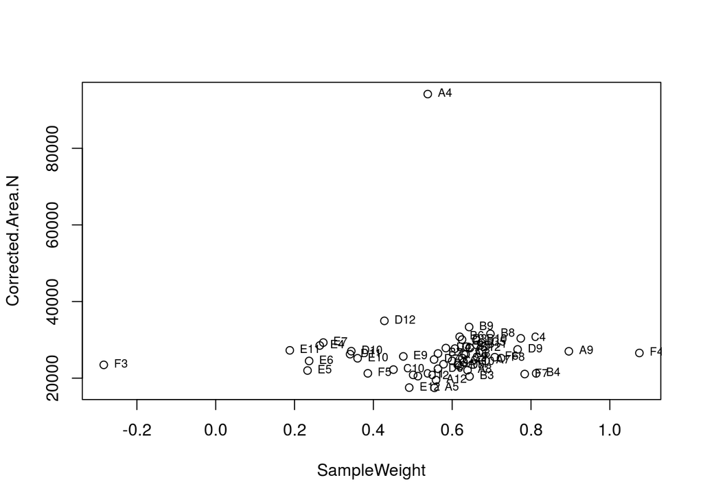

#### 2. Corrected.Area.C ~ SampleWeight

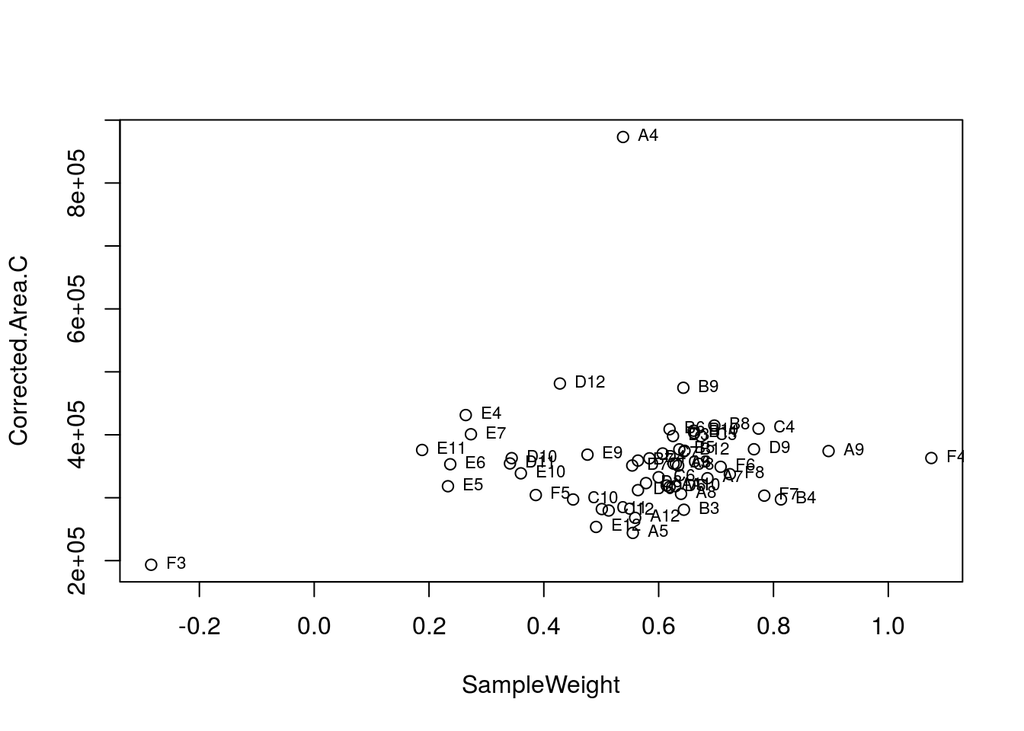

#### 3. Weight.N.perCup ~ SampleWeight

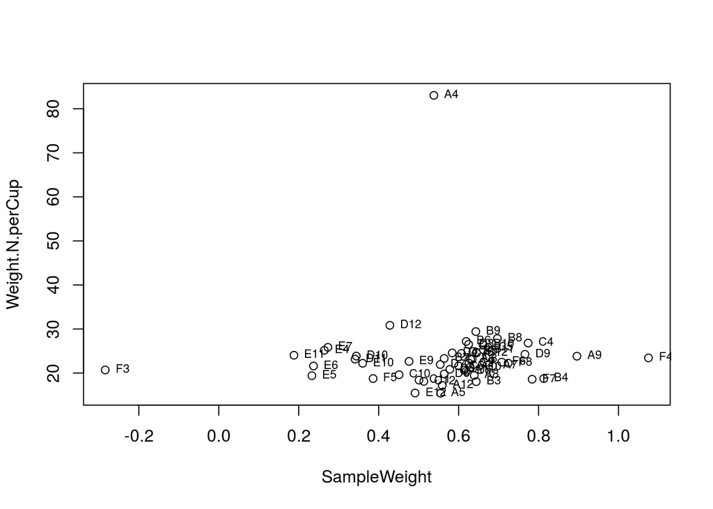

#### 4. Weight.C.perCup ~ SampleWeight

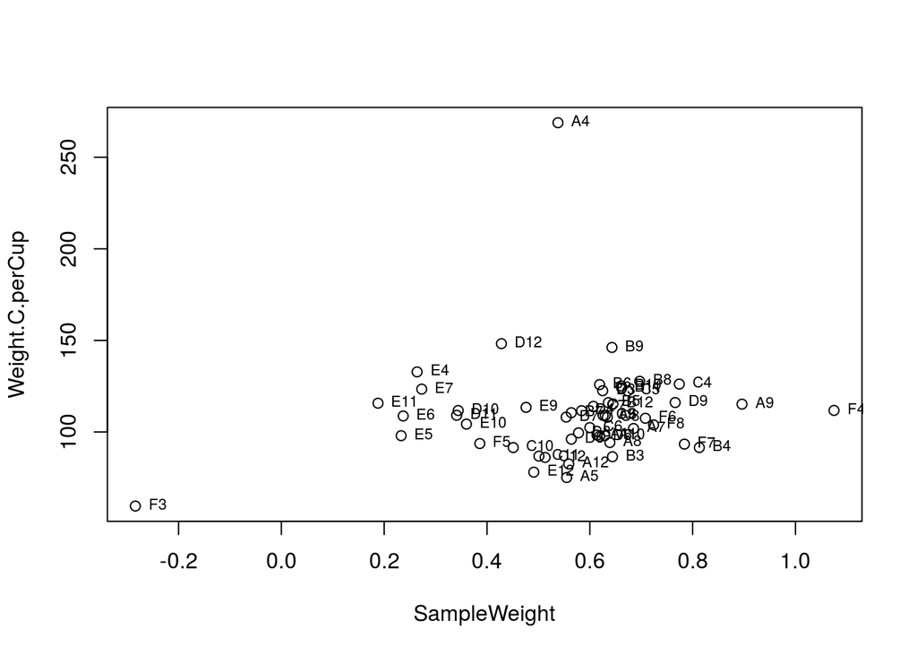

#### 5. Weight.N.kg ~ SampleWeight

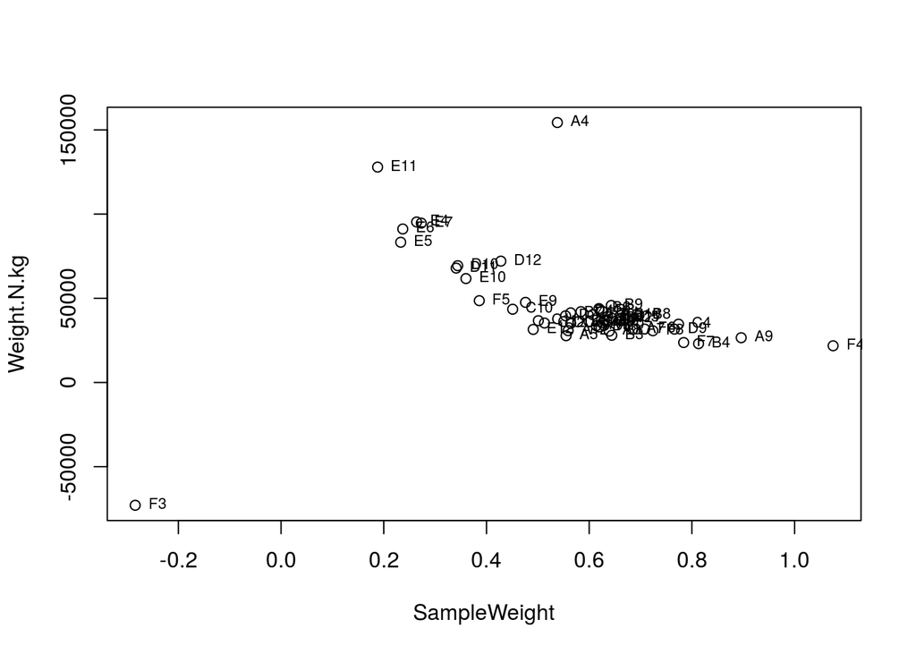

#### 6. Weight.C.kg ~ SampleWeight

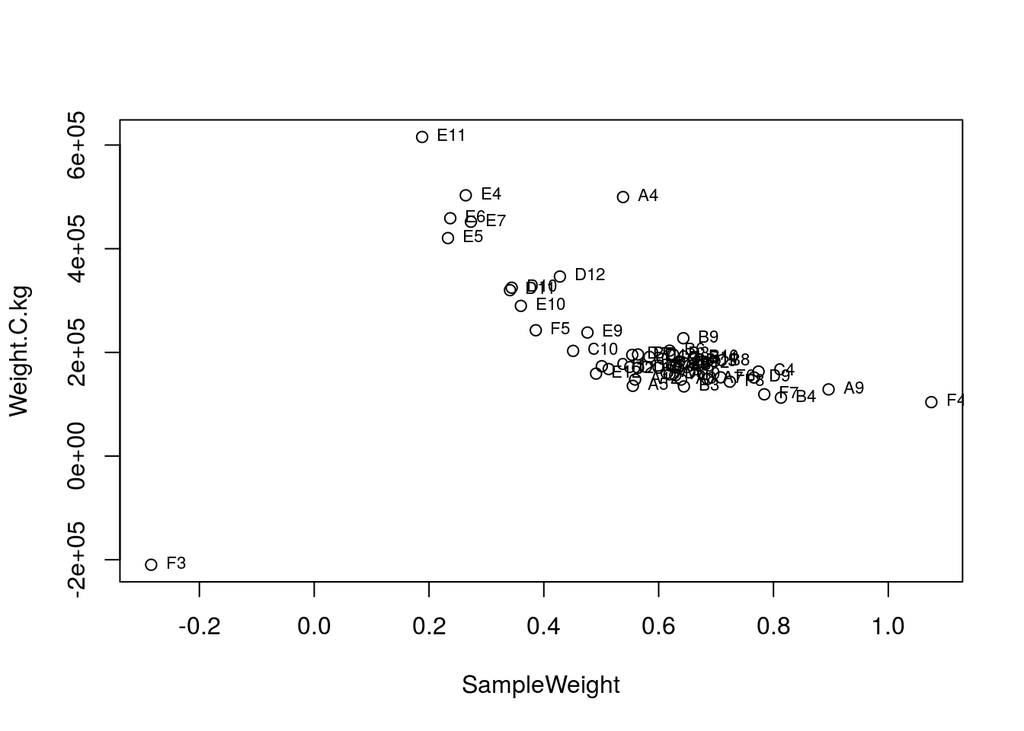

#### 7. C.N.Ratio ~ SampleWeight

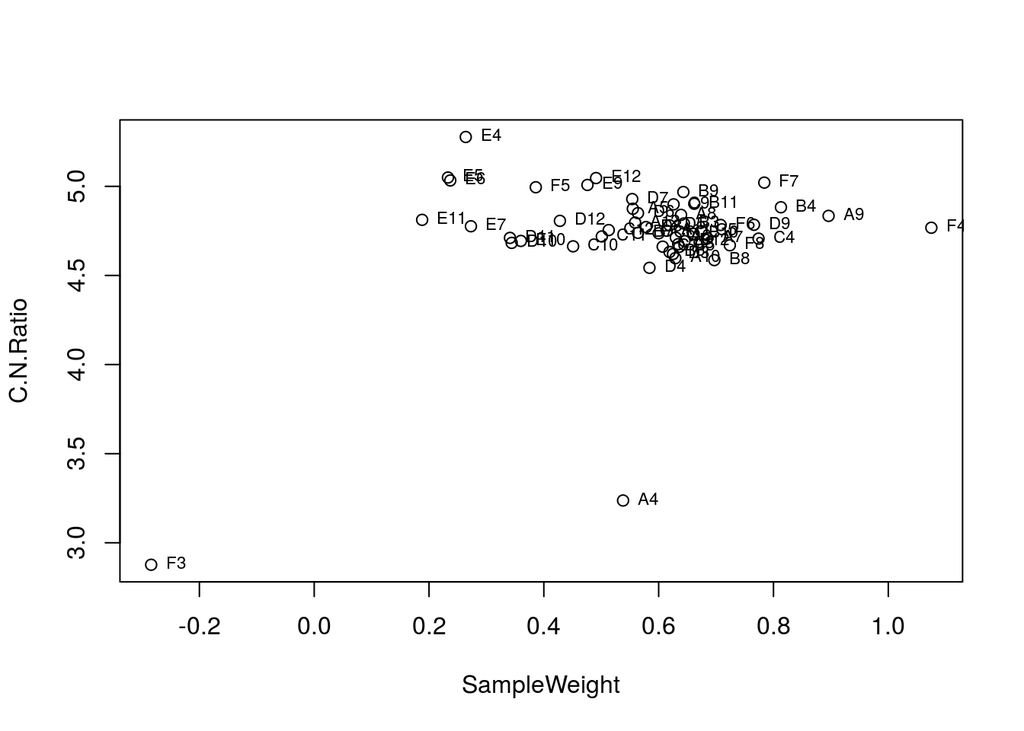